# IODS course project

## Regression modelling

I chose to make the model using attitude, age and strategic learning variables as explanatory variables. When using linear model (lm()) it will be created by following structure: lm(depend variable ~ explanatory variable 1 + explanatory variable 2 + …, data = data that includes all the variables). After creating the model the summary() -command will show all the important information about the created model.

```r
#Create linear model
model <- lm(points ~ attitude + stra + age, data = data)

#show coefficients in a tidy form
tidy(model)
```

```
## # A tibble: 4 × 5
##   term        estimate std.error statistic       p.value
##   <chr>          <dbl>     <dbl>     <dbl>         <dbl>
## 1 (Intercept)  10.9       2.65        4.11 0.0000617
## 2 attitude      3.48      0.562       6.19 0.00000000472
## 3 stra          1.00      0.534       1.88 0.0621
## 4 age          -0.0882    0.0530     -1.66 0.0981
```

```r
#Print out the model summary
summary(model)
```

```
##
## Call:
## lm(formula = points ~ attitude + stra + age, data = data)
##
## Residuals:
##      Min       1Q   Median       3Q      Max
## -18.1149  -3.2003   0.3303   3.4129  10.7599
##
## Coefficients:
##             Estimate Std. Error t value Pr(>|t|)
## (Intercept) 10.89543    2.64834   4.114 6.17e-05 ***
## attitude     3.48077    0.56220   6.191 4.72e-09 ***
## stra         1.00371    0.53434   1.878   0.0621 .
## age         -0.08822    0.05302  -1.664   0.0981 .
## ---
## Signif. codes:  0 '***' 0.001 '**' 0.01 '*' 0.05 '.' 0.1 ' ' 1
##
## Residual standard error: 5.26 on 162 degrees of freedom
## Multiple R-squared:  0.2182, Adjusted R-squared:  0.2037
## F-statistic: 15.07 on 3 and 162 DF,  p-value: 1.07e-08
```

To get the wanted results to show more appealing for i will use tidy() -command from the broom library. In addition to the summary command that will also show important information.

In summary() -output the residual part indicates how the residuals are distributed. Median value is close to zero, which could indicate that the results could be close to normal distribution, but max and min values indicate that the distribution is slightly off from normal distribution.

When interpreting the results based on coefficients few observations can be made:

- If all the explanatory variables are 0, the points awarded from exam would be 10.89
- Increase in attitude value will increase received points by 3.4
- Increase in strategic learning questions value will increase received points by 1
- Increase in age will lower the received points by 0.09.

Multiple R-squared value for the model is 0.2182 meaning that the model is only explaining 21% of the variation in the points. Multiple R-squared value is good indicator for how well the model is working and how reliable it is when studying the results. In this case it would be beneficial to try changing the variables so the model would work better. (Adjust R-square on the other hand has little bit lower value because its value drops if there is variable in the model that does not help to improve the model in a certain level.)

To study the results even more, it is time to plot them. Par() -command is used to make all the visuals appear in the same row. Plot() -command is used to print out the pictures.

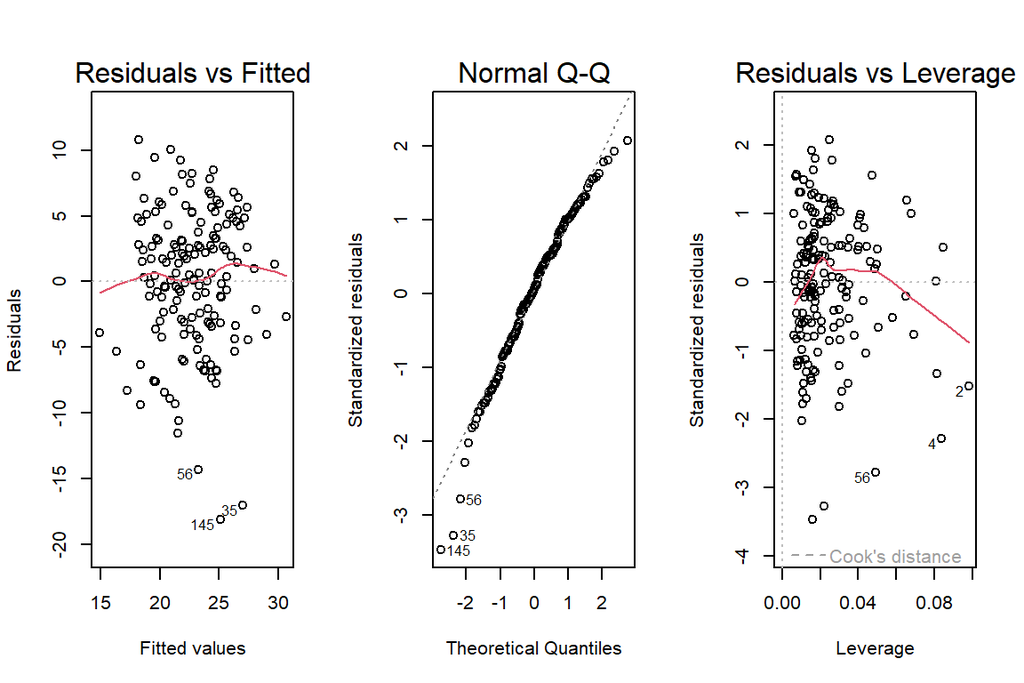

```r
#define the plotting area, so there is one row and three "columns/plots" in that row. After that use the plot command to plot wanded plots defined by which attribute.
par(mfrow = c(1,3))
plot(model, which= c(1,2,5))
```

Residuals vs Fitted values -plot shows that residuals form a line that loosely follows the 0 line. This suggest that the assumption of linear relationship between variables is reasonable. There is still few outliers that don’t follow the overall pattern. The line could be better, but it does not indicate that the model/ data has significant problems. If the line is more parabolic then it would indicate that the model need a quadratic term in the explanatory variable, but just a mild curve it is not quite enough to make that kind of change.

QQ-plot (quantile-quantile -plot) shows if the data is conditionally normal. The closer the points are on the line the closer the data is to normality. Now it shows that lowest residuals and the highest residuals are not in the line as well as the residuals in the middle. Overall the residuals are very close to a normal distribution indicating that p-values and confidence intervals that model produced can be trusted.

Residuals vs Leverage plot is created so it is possible to see if there is outliers in the data. If there is outliers (values that are not approximated well in the model), they have large residual value and it creates large leverage in the model. The results line is not straight, but turns to a steep descent indicating that there is outliers in the data. So there could be values that are not modeled correctly, rather, they score too high or too low when modeling the results. Because of this the model could be better and when studying the results it is important to investigate what kind of situations course the model not work properly.

Overall the model is okay, it is not best to describe the points distribution but it is not wrong ether. Because the model only explanes 21% of the variation in points, and it contains outliers that the residuals vs leverage plot is showing, it would not be useful predicting points. It may work correctly on predicting middle points, but it most likely will be wrong in high/low points. It could work better if the age and stra variables are changed to variables with higher statistical significance.

# Chapter 3 Assignment 3, Logistic regression

```r
date()
```

```
## [1] "Mon Dec 11 17:25:03 2023"
```

## Libraries

```r
library(tidyverse)
library(dplyr)
library(ggplot2)
library(boot)
```

## Read the Data

Read in the data that has been made in the previous data wrangling part. I will use the read_csv -command from the tidyverse -library to do that.

```r
#read in the data. read_csv -command assumes that the separator is , so there is no need for further explanations in the code
data <- read_csv("data/alc.csv")
#print out the column names
colnames(data)
```

```
##  [1] "school"     "sex"        "age"        "address"    "famsize"
##  [6] "Pstatus"    "Medu"       "Fedu"       "Mjob"       "Fjob"
## [11] "reason"     "guardian"   "traveltime" "studytime"  "schoolsup"
## [16] "famsup"     "activities" "nursery"    "higher"     "internet"
## [21] "romantic"   "famrel"     "freetime"   "goout"      "Dalc"
## [26] "Walc"       "health"     "failures"   "paid"       "absences"
## [31] "G1"         "G2"         "G3"         "alc_use"    "high_use"
```

Data includes 35 columns and 370 rows. It includes answers from math and Portuguese language course students. First columns include some background information like school, gender, age, address, family size, romantic relationship, free time, activities etc. In addition the data sets includes information about workday and weekend alcohol consumption. Based on these two column answers there has been added columns, alc_use and high_use, to indicate how much alcohol person is drinking. And lastly there is columns G1, G2, and G3 that indicate for what grade did the person got after each period.

## Background for the analysis

I chose to do the analysis with absences, freetime, goout and studytime.

My hypotheses are following:

1. increase in free time will mildly lead to higher alcohol consumption, because then you might have more time to do it.
2. Study time on the other hand might lower the amount of alcohol consumption because then person could use the time in workdays (and even weekends) for studying.
3. Go out is probably going to rise the amount of alcohol, because usually people drink alcohol when partying and going out.
4. And lastly absences might be a consequence of drinking alcohol, so there might be positive relationship between those variables.

Exploring the chosen variables:

```r
#Absences
#Numeric values
data$absences %>% mean
```

```
## [1] 4.510811
```

```r
data$absences %>% min
```

```
## [1] 0
```

```r
data$absences %>% max
```

```
## [1] 45
```

```r
#table for the distribution of the answers
table(high_use = data$high_use, absences = data$absences)
```

```
##         absences
## high_use  0  1  2  3  4  5  6  7  8  9 10 11 12 13 14 16 17 18 19 20 21 26 27
##    FALSE 50 37 40 31 24 16 16  9 14  5  5  2  3  1  1  0  0  1  0  2  1  0  0
##    TRUE  13 13 16  7 11  6  5  3  6  6  2  3  4  1  6  1  1  1  1  0  1  1  1
##         absences
## high_use 29 44 45
##    FALSE  0  0  1
##    TRUE   1  1  0
```

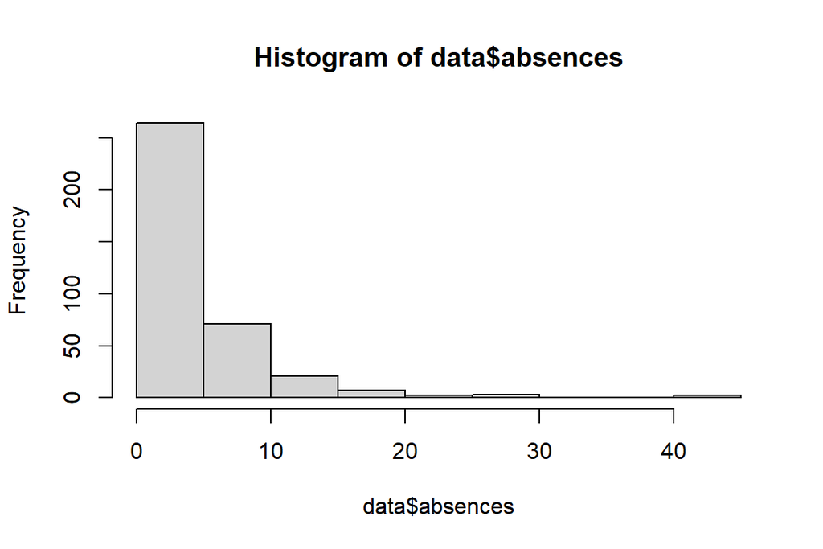

```r
#Check the distribution of the variable
hist(data$absences)
```

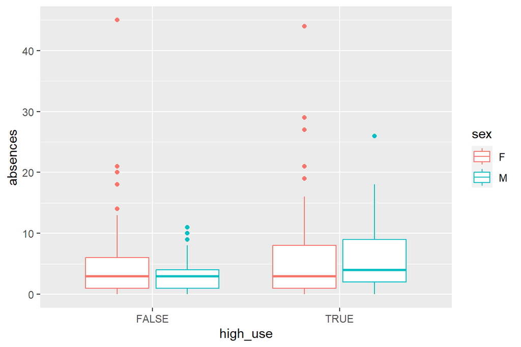

```r
#plot the "relationship" between response variable and explanatory variable
absences_plot <- ggplot(data, aes(x = high_use, y = absences,col = sex))

# define the plot as a box plot and draw it
absences_plot + geom_boxplot()
```

Numerically absences varied between 0 and 45 absences and on average there were about 4.5 absences. From the histogram is possible to see that most people have less than 10 absences and there is only few people with more than 20 absences. Based on the box plot it would seem that there is little bit greater range in absences for people with high alcohol consumption. Also the median value might be little bit higher for men who drink more alcohol than those how drink less. But it cannot be said unequivocally that higher alcohol consumption leads to more absences. Still there might be positive correlation between those two variables. Also the boxplot might not be the best choice to interpret the relationship between these two variables, but it was the one that was used in the exercises so i used it as well.

```r
#free time
#Numeric values
data$freetime %>% mean
```

```
## [1] 3.224324
```

```r
data$freetime %>% min
```

```
## [1] 1
```

```r
data$freetime %>% max
```

```
## [1] 5
```

```r
#table for the distribution of the answers
table(high_use = data$freetime, freetime = data$freetime)
```

```
##         freetime
## high_use   1   2   3   4   5
##        1  17   0   0   0   0
##        2   0  60   0   0   0
##        3   0   0 152   0   0
##        4   0   0   0 105   0
##        5   0   0   0   0  36
```

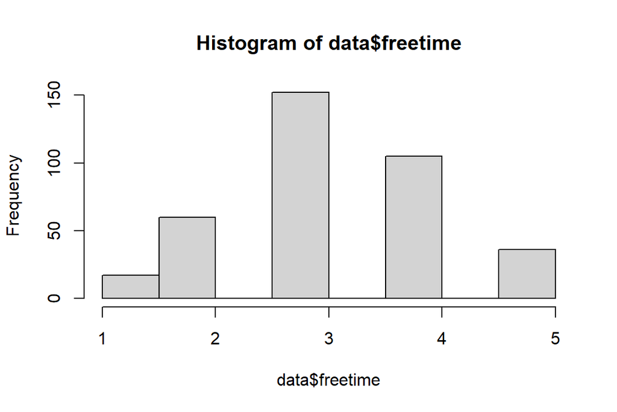

```r
#Check the distiribution of the variable
hist(data$freetime)
```

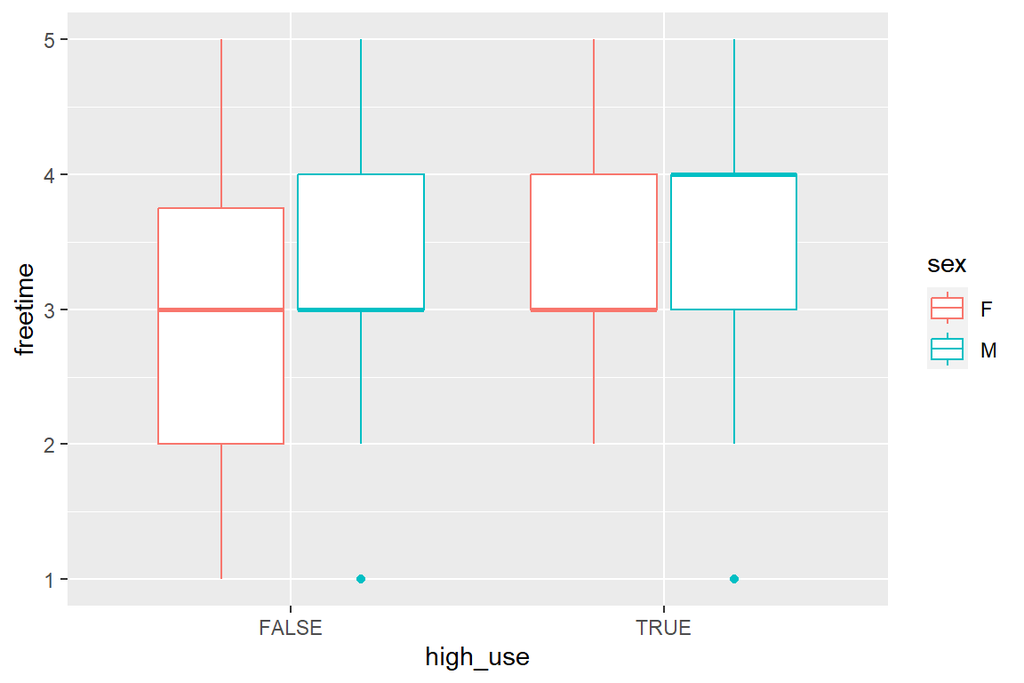

```r
#plot the "relationship" between response variable and explanatory variable
freetime_plot <- ggplot(data, aes(x = high_use, y = freetime,col = sex))

# define the plot as a box plot and draw it
freetime_plot + geom_boxplot()
```

Distribution of the free time is almost normally distributed but not quite. Most popular answer has been 3 and the highest and lowest values are the least popular ones. There does not seem to be any correlation that can be interpreted from the graph in the amount of free time and alcohol consumption. The only noticeable differences are the variation in the median values (especially men who drink less alcohol vs more alcohol), as well as the larger range of variation in the amount of free time for women who consume little alcohol. Based on these, however, it is not possible to make interpretations about the relationship between the variables. Free time has been measured on a scale of 1-5, which partly explains why the ranges are very identical for different alcohol consumption groups.

```r
#Going out
#Numeric values
data$goout %>% mean
```

```
## [1] 3.116216
```

```r
data$goout %>% min
```

```
## [1] 1
```

```r
data$goout %>% max
```

```
## [1] 5
```

```r
#table for the distribution of the answers
table(high_use = data$goout, goout = data$goout)
```

```
##         goout
## high_use   1   2   3   4   5
##        1  22   0   0   0   0
##        2   0  97   0   0   0
##        3   0   0 120   0   0
##        4   0   0   0  78   0
##        5   0   0   0   0  53
```

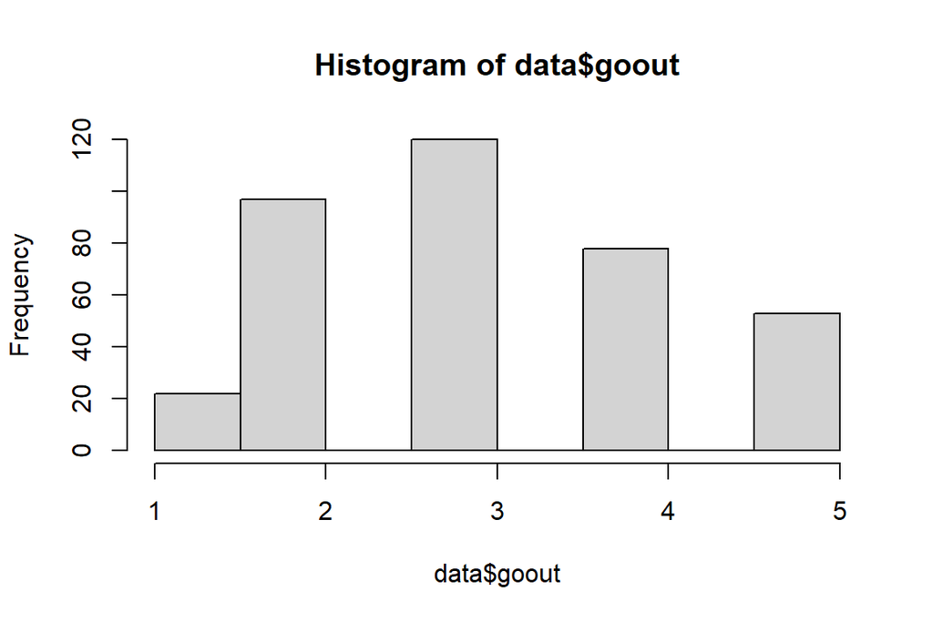

```r
#Histogram about the distribution
hist(data$goout)
```

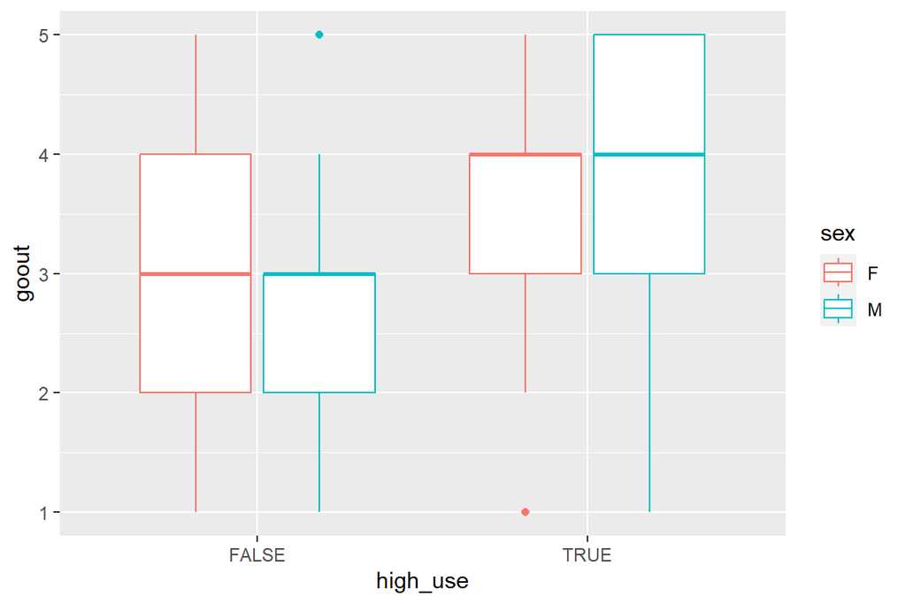

```r
#plot the "relationship" between response variable and explanatory variable
goout_plot <- ggplot(data, aes(x = high_use, y = goout,col = sex))

# define the plot as a box plot and draw it
goout_plot + geom_boxplot()
```

In terms of numbers, the going out is in the same category as free time, meaning that there is not difference between min, max or mean values. Histogram show a difference because there difference in the distribution of lower and higher values. Difference is also clearly visible in the diagram. The going out numbers are clearly higher for the people how drink more alcohol than people who do not drink as much. This means that my hypothesis might be right.

```r
#study time
#Numeric values
data$studytime %>% mean
```

```
## [1] 2.043243
```

```r
data$studytime %>% min
```

```
## [1] 1
```

```r
data$studytime %>% max
```

```
## [1] 4
```

```r
#table for the distribution of the answers
table(high_use = data$studytime, studytime = data$studytime)
```

```
##         studytime
## high_use   1   2   3   4
##        1  98   0   0   0
##        2   0 185   0   0
##        3   0   0  60   0
##        4   0   0   0  27
```

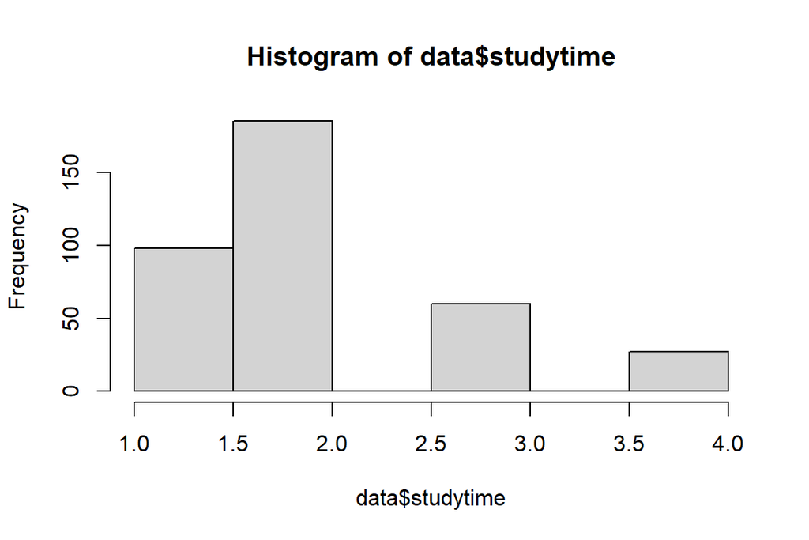

```r
#Histogram about the distribution
hist(data$studytime)
```

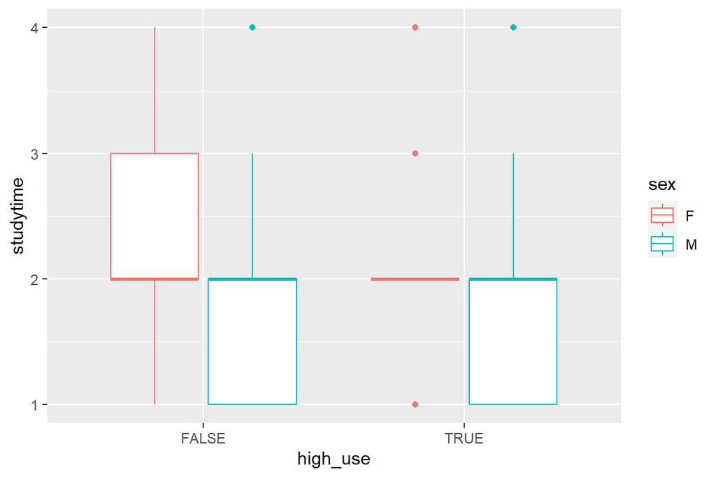

```r
#plot the "relationship" between response variable and explanatory variable
studytime_plot <- ggplot(data, aes(x = high_use, y = studytime,col = sex))

# define the plot as a box plot and draw it
studytime_plot + geom_boxplot()
```

Most popular answer for study time has been 2, and there is zero answer on the option 5. There also has been more answers on the lower end than higher end.

Well for women my hypothesis might be true, but it is impossible to say. All the median values are in the same line, so based on those values it looks like that there might not be any correlation between study time and alcohol consumption.

## Logistic regression

Next i created a model that uses high use as a response variable and free time, absences, study time and going out as explanatory variables.

```r
# create the glm model
model <- glm(high_use ~ freetime + absences + goout + studytime, data = data, family = "binomial")

# print out a summary of the model
summary(model)
```

```
##
## Call:
## glm(formula = high_use ~ freetime + absences + goout + studytime,
##     family = "binomial", data = data)
##
## Deviance Residuals:
##     Min       1Q   Median       3Q      Max
## -1.8093  -0.7608  -0.5330   0.8403   2.5375
##
## Coefficients:
##             Estimate Std. Error z value Pr(>|z|)
## (Intercept) -2.79253    0.65404  -4.270 1.96e-05 ***
## freetime     0.13726    0.13915   0.986 0.323932
## absences     0.07113    0.02234   3.185 0.001449 **
## goout        0.68881    0.12315   5.593 2.23e-08 ***
## studytime   -0.56836    0.16872  -3.369 0.000755 ***
## ---
## Signif. codes:  0 '***' 0.001 '**' 0.01 '*' 0.05 '.' 0.1 ' ' 1
##
## (Dispersion parameter for binomial family taken to be 1)
##
##     Null deviance: 452.04  on 369  degrees of freedom
## Residual deviance: 376.18  on 365  degrees of freedom
## AIC: 386.18
##
## Number of Fisher Scoring iterations: 4
```

```r
# print out the coefficients of the model
coef(model)
```

```
## (Intercept)    freetime    absences       goout   studytime
##  -2.7925341   0.1372592   0.0711320   0.6888093  -0.5683601
```

In the model only the free time variable is not statistically significant. AIC value is quite large, implicating that the model does not work as good as it could, but i don’t yet have another model to compare the value to so i cant look into it too closely. Residuals are definetly not normally distributed. Based on the null deviance and residual deviance it is possible to count that the deviance explained is (452.04 - 376.18)/452.04 = 0.167817, meaning that the model explains 17% of the variation in the response variable. Based on the coefficients the study time is affecting negatively to the high alcohol consumption and all other variables are affecting positively.

```r
# calculate the odds ratio from the coefficients
OR <- coef(model) %>% exp

# calculate the confidence intervals
CI <- confint(model)
# print out the results
cbind(OR, CI)
```

```
##                     OR       2.5 %     97.5 %
## (Intercept) 0.06126577 -4.10648531 -1.5358242
## freetime    1.14712539 -0.13498664  0.4121332
## absences    1.07372294  0.02835488  0.1171089
## goout       1.99134295  0.45337192  0.9373475
## studytime   0.56645361 -0.91013321 -0.2465699
```

## Final model

Because free time is not statistically significant i will remove it from the final model. My hypothesis with free time seems to be true because the coefficients implicate that the relationship between free time and high alcohol consumption is positive, meaning that more free time will more likely to lead to more alcohol use. But because the relationship is not statistically significant the model is probably better without it.

```r
# create the glm model
model <- glm(high_use ~ absences + goout + studytime, data = data, family = "binomial")

# print out a summary of the model
summary(model)
```

```
##
## Call:
## glm(formula = high_use ~ absences + goout + studytime, family = "binomial",
##     data = data)
##
## Deviance Residuals:
##     Min       1Q   Median       3Q      Max
## -1.8398  -0.7683  -0.5123   0.8370   2.5075
##
## Coefficients:
##             Estimate Std. Error z value Pr(>|z|)
## (Intercept) -2.42597    0.53367  -4.546 5.47e-06 ***
## absences     0.06932    0.02222   3.119 0.001814 **
## goout        0.72453    0.11860   6.109 1.00e-09 ***
## studytime   -0.58165    0.16824  -3.457 0.000546 ***
## ---
## Signif. codes:  0 '***' 0.001 '**' 0.01 '*' 0.05 '.' 0.1 ' ' 1
##
## (Dispersion parameter for binomial family taken to be 1)
##
##     Null deviance: 452.04  on 369  degrees of freedom
## Residual deviance: 377.16  on 366  degrees of freedom
## AIC: 385.16
##
## Number of Fisher Scoring iterations: 4
```

```r
# print out the coefficients of the model
coef(model)
```

```
## (Intercept)    absences       goout   studytime
## -2.42597045  0.06932029  0.72452590 -0.58165169
```

Now i have the final model i can use it to predict the high alcohol consumption. Before predicting the summary output of the new model is almost same as the last model. The AIC value is little bit smaller, but not significantly. The good difference is that now all the explanatory variables are statistically significant (p < 0.05). It looks like that the absences and going out are increasing the response variable and study time is decreasing it, meaning that my earlier hypothesis might still be true.

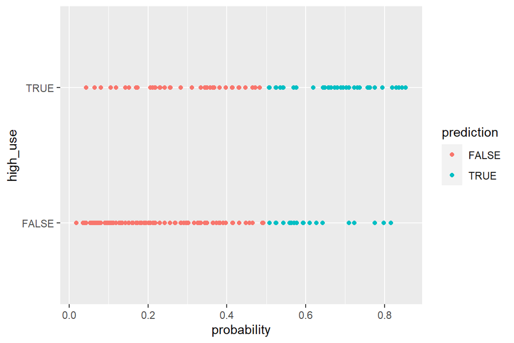

```r
#predict the probabilities and safe them in new column in the data set
data <- mutate(data, probability = predict(model, type = "response"))

#add the prediction column in the data
data <- mutate(data, prediction = probability > 0.5)


##########################

#Visualize the results

#define the plot
plot_predic <- ggplot(data, aes(x = probability, y = high_use, col = prediction))

#draw the plot
plot_predic + geom_point()
```

```r
# first print out just the predicted answer amounts and correct amounts
table(high_use = data$high_use, prediction = data$prediction)
```

```
##         prediction
## high_use FALSE TRUE
##    FALSE   237   22
##    TRUE     64   47
```

```r
#print out all so the probabilities
table(high_use = data$high_use, prediction = data$prediction) %>% prop.table() %>% addmargins()
```

```
##         prediction
## high_use      FALSE       TRUE        Sum
##    FALSE 0.64054054 0.05945946 0.70000000
##    TRUE  0.17297297 0.12702703 0.30000000
##    Sum   0.81351351 0.18648649 1.00000000
```

Based both on the visualization of the results and the table presentation, it looks like that the model is most of the time predicting that the person is not a high user, and fewer times predicting that the alcohol consumption is on the higher end.

## Guessing the results

We want to know can the model perform better than a simple guess, so we can use loss function for that.

```r
# define a loss function (average prediction error)
loss_func <- function(class, prob) {
  n_wrong <- abs(class - prob) > 0.5
  mean(n_wrong)
}

# compute the average number of wrong predictions in the (training) data
loss_func(class = data$high_use, prob = data$probability)
```

```
## [1] 0.2324324
```

```r
#compute the error if none of the people is high user
loss_func(class = data$high_use, prob = 0)
```

```
## [1] 0.3
```

```r
#compute the error if every one is high user
loss_func(class = data$high_use, prob = 1)
```

```
## [1] 0.7
```

Okey, looks like that my model has a error rate of 0.23 and if we just guess that none of the people is high alcohol user the result is 0.3. This means that my model is more correct than a simple guess, luckily.

```r
# K-fold cross-validation

validation <- cv.glm(data = data, cost = loss_func, glmfit = model, K = nrow(data))

# average number of wrong predictions in the cross validation

validation$delta[1]
```

```
## [1] 0.2351351
```

My model haves a little bit better test set performance than the model in the Exercise set. Exercise set got the performance value about 0.24 and i have just under that 0.235, but only just…